# Sol1_Linear_Regression

## Technical TASK 1 :- Prediction using Supervised ML

In this task, we will predict the percentage of marks that a student is expected to score based upon the number of hours they studied. This is a simple linear regression task as it involves just two variables.

Task Completed for The Sparks Foundation Internship Program

## Data Science & Business Analytics Internship Task_1

### Author: Ranjith Kumar

## Step 0: Importing Libraries needed to perform simple Linear Regression

```python
# Importing all libraries required in this notebook
import pandas as pd
import numpy as np
import matplotlib.pyplot as plt
import seaborn as sns
import sklearn
from sklearn import linear_model
from sklearn.utils import shuffle
import pickle
```

## Step 1 : Reading Data from csv

```python
# Reading data from remote link
url = "/content/New Text Document.csv"
std = pd.read_csv(url)

std.head(10)
```

|  | Hours | Scores |
| --- | --- | --- |
| 0 | 2.5 | 21 |
| 1 | 5.1 | 47 |
| 2 | 3.2 | 27 |
| 3 | 8.5 | 75 |
| 4 | 3.5 | 30 |
| 5 | 1.5 | 20 |
| 6 | 9.2 | 88 |
| 7 | 5.5 | 60 |
| 8 | 8.3 | 81 |
| 9 | 2.7 | 25 |

```python
std.info()
```

```
<class 'pandas.core.frame.DataFrame'>
RangeIndex: 25 entries, 0 to 24
Data columns (total 2 columns):
 #   Column  Non-Null Count  Dtype
---  ------  --------------  -----
 0   Hours   25 non-null     float64
 1   Scores  25 non-null     int64
dtypes: float64(1), int64(1)
memory usage: 528.0 bytes
```

```python
std.describe()
```

|  | Hours | Scores |
| --- | --- | --- |
| count | 25.000000 | 25.000000 |
| mean | 5.012000 | 51.480000 |
| std | 2.525094 | 25.286887 |
| min | 1.100000 | 17.000000 |
| 25% | 2.700000 | 30.000000 |
| 50% | 4.800000 | 47.000000 |
| 75% | 7.400000 | 75.000000 |
| max | 9.200000 | 95.000000 |

## Step 2 : Data Visualization

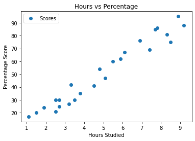

```python
std.plot(x='Hours', y='Scores', style='o')
plt.title('Hours vs Percentage')
plt.xlabel('Hours Studied')
plt.ylabel('Percentage Score')
plt.show()
```

```
The relation Matrix
```

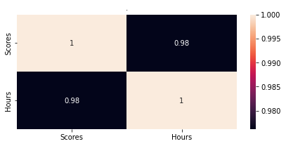

```python
# Here the heatmap shows positive correlation between the Hours column and Scores column.
plt.figure(figsize=(7,3))
sns.heatmap(std[['Scores','Hours']].corr(), annot = True)
plt.title('.', fontsize = 10)
print('The relation Matrix')
plt.show()
```

##### Now let's plot our data points on 2-D graph to eyeball our dataset and see if we can manually find any relationship between the data. We can create the plot with the following script:

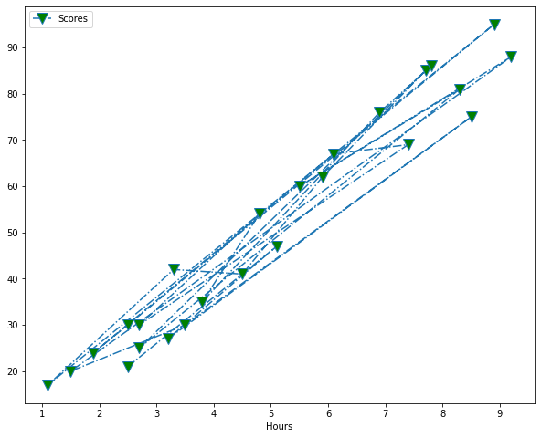

```python
std.plot("Hours","Scores",linestyle = "-.",marker = "v",markersize = "12",markerfacecolor = "green", figsize=(10,8))
```

## Step 3 : Preparing The Data

The next step is to divide the data into "attributes"/"X" (inputs) and "labels"/"Y" (outputs).

```python
x = std.iloc[:, :-1].values
y = std.iloc[:, 1].values
```

## Step 4 : Algorithm Training

Splitting the data into training data-set and test data-set.

```python
#defining training and testing sets ## we'll let the test size be equal to 0.1
x_train, x_test, y_train, y_test = sklearn.model_selection.train_test_split(x,y, test_size=0.1)
```

### **Training the Algorithm**

We have split our data into training and testing sets, and now is finally the time to train our algorithm.

```python
best = 0
for _ in range(15):
    x_train, x_test, y_train, y_test = sklearn.model_selection.train_test_split(x,y, test_size=0.2)

    linear = linear_model.LinearRegression()
    linear.fit(x_train, y_train) # fit this data  to get best fit line...
    acc = linear.score(x_test, y_test) # this will gona return the accuracy value of  out model
    #print("Accuracy: ",acc) #Change in Every Run best of data size, every time different data will be used...

    if acc > best:
        best = acc
        with open("student_model.pickle", "wb") as f: #opening student_model.pickle in write-binary mode as f to write
            pickle.dump(linear, f) #pickle saving the object into file
print(" Best Accuracy: ",best)
```

```
 Best Accuracy:  0.9716606946809869
```

Training Done!!

## Step 5 :- Ploting the line of regression

[figure not shown]

```python
# Plotting the regression line
line = regressor.coef_*X+regressor.intercept_

# Plotting for the test data
plt.scatter(X, y)
plt.plot(X, line);
plt.show()
```

## Step 6 :- Making Predictions

Now that we have trained our algorithm, it's time to make some predictions.

```python
pickle_in = open("student_model.pickle", "rb") #opening student_model.pickle in read-binary mode to read
linear = pickle.load(pickle_in) #loading model in variable(linear)
prediction = linear.predict(x_test)
print(x_test,prediction)
```

```
[[2.5]
 [7.7]
 [5.5]
 [4.5]
 [4.8]] [26.5250093  78.17363928 56.32229583 46.38986698 49.36959564]
```

```python
std1 = pd.DataFrame({'Actual': y_test, 'Predicted': prediction})
```

```python
std1
```

|  | Actual | Predicted |
| --- | --- | --- |
| 0 | 30 | 26.525009 |
| 1 | 85 | 78.173639 |
| 2 | 60 | 56.322296 |
| 3 | 41 | 46.389867 |
| 4 | 54 | 49.369596 |

```python
### Estimating the Training Data and Test Data Score
print("Training score:", linear.score(x_train, y_train))
print("Testing score:", linear.score(x_test, y_test))
```

```
Training score: 0.955536216519768
Testing score: 0.9295685535314155
```

```python
### Testing your own data.
hours = 9.25
test = np.array([hours])
test = test.reshape(-1,1)
own_pred = linear.predict(test)
print ("No. of Hours = {}".format(hours))
print ("Predicted Score = {}".format(own_pred[0]))
```

```
No. of Hours = 9.25
Predicted Score = 93.56890398342159
```

## Step 8 : Evaluating the model

The final step is to evaluate the performance of algorithm. This step is particularly important to compare how well different algorithms perform on a particular dataset. For simplicity here, we have chosen the mean square error. There are many such metrics.

```python
from sklearn import metrics
print('Mean Absolute Error:', metrics.mean_absolute_error(y_test, prediction))
print('Mean Squared Error:', metrics.mean_squared_error(y_test, prediction))
print('Root mean squared Error:', np.sqrt(metrics.mean_squared_error(y_test, prediction)))
```

```
Mean Absolute Error: 4.799865389043374
Mean Squared Error: 24.538315949654805
Root mean squared Error: 4.95361645160935
```